# Part II - Usage Pattern within Ford GoBike System

## by Xinyi Liao

## Investigation Overview

> In this investigation, I'm interested in what features are the best to identify common usage patterns. The main focus was about hours, days, and duration of the trips, member information such as member types, gender.

## Dataset Overview

> The data consists of information regarding the rides taken in February, 2019, within the Ford GoBike System of the greater San Francisco Bay area. The data originally contains 16 attributes, including details such as duration, start and end times, station locations, user type, and demographic information of the trips. The data was cleaned for better visualization and analysis.

## User Type Distribution

> In user base, subscribers accounted for 90.5%, and customers are 9.5%

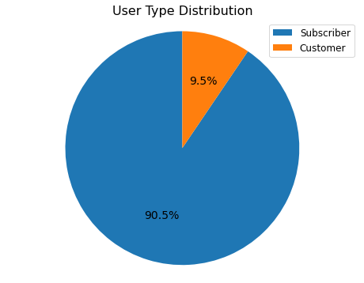

## Trip Counts by User Type in Hours and Days

> Subscribers had a lot more usage activities than Customers since Subscribers made up a significant portion of the user base. Most likely, Subscribers used the service for work commute purpose, obviously during typical rush hours at 8 a.m. or 5 p.m. In Subecriber user group, the service was used more heavily during weekdays. For Customers, they had a more stable trip counts at any time segiments.

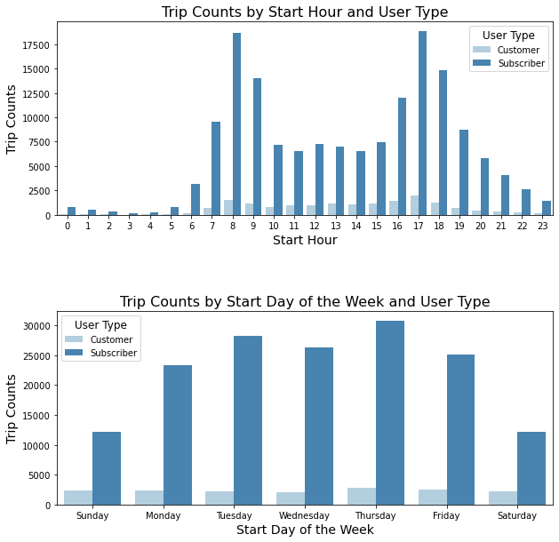

## Trip Duration by User Type

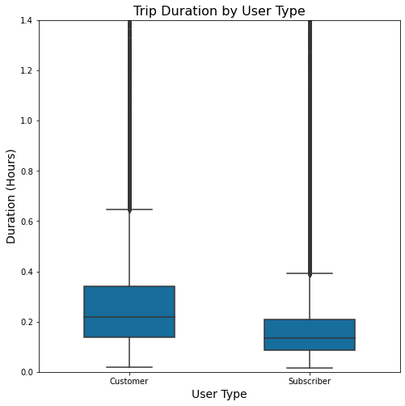

## Average Trip Duration by Day and User Type

> On Saturdays and Sundays, both user categories experienced an increase in trip time, particularly customers. Subscriber usage was more efficient than Customers usage overall, with a fairly stable average durations from Monday to Friday.

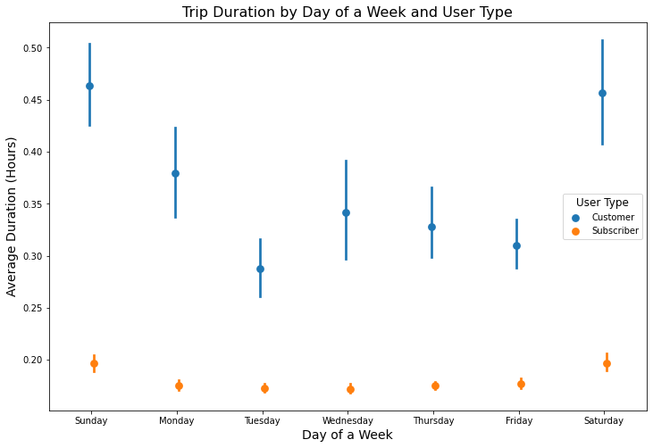